# Data Visualization - Line Plotting

#### Preparing the enviroment

```python
import numpy as np
import pandas as pd
import openpyxl # used to read excel files
```

#### Enter the url where your dataset is:

```python
URL = 'https://github.com/mmouty/energynds/blob/main/energynds/assets/datasets/UN_MigFlow_All_CountryFiles.zip'
```

#### fetching the excel file:

```python
df_can = pd.read_excel(
    URL,
    sheet_name='Canada by Citizenship',
    skiprows=range(20),
    skipfooter=2,
    engine='openpyxl')
print('Data downloaded and read into a dataframe!')
```

```
Data downloaded and read into a dataframe!
```

```python
df_can.head() #Just checking the data
```

|  | Type | Coverage | OdName | AREA | AreaName | REG | RegName | DEV | DevName | 1980 | ... | 2012 | 2013 | Unnamed: 43 | Unnamed: 44 | Unnamed: 45 | Unnamed: 46 | Unnamed: 47 | Unnamed: 48 | Unnamed: 49 | Unnamed: 50 |
| --- | --- | --- | --- | --- | --- | --- | --- | --- | --- | --- | --- | --- | --- | --- | --- | --- | --- | --- | --- | --- | --- |
| 0 | Immigrants | Foreigners | Afghanistan | 935.0 | Asia | 5501.0 | Southern Asia | 902.0 | Developing regions | 16.0 | ... | 2635.0 | 2004.0 | NaN | NaN | NaN | NaN | NaN | NaN | NaN | NaN |
| 1 | Immigrants | Foreigners | Albania | 908.0 | Europe | 925.0 | Southern Europe | 901.0 | Developed regions | 1.0 | ... | 620.0 | 603.0 | NaN | NaN | NaN | NaN | NaN | NaN | NaN | NaN |
| 2 | Immigrants | Foreigners | Algeria | 903.0 | Africa | 912.0 | Northern Africa | 902.0 | Developing regions | 80.0 | ... | 3774.0 | 4331.0 | NaN | NaN | NaN | NaN | NaN | NaN | NaN | NaN |
| 3 | Immigrants | Foreigners | American Samoa | 909.0 | Oceania | 957.0 | Polynesia | 902.0 | Developing regions | 0.0 | ... | 0.0 | 0.0 | NaN | NaN | NaN | NaN | NaN | NaN | NaN | NaN |
| 4 | Immigrants | Foreigners | Andorra | 908.0 | Europe | 925.0 | Southern Europe | 901.0 | Developed regions | 0.0 | ... | 1.0 | 1.0 | NaN | NaN | NaN | NaN | NaN | NaN | NaN | NaN |

5 rows × 51 columns

#### Let's get basic information about our dataframe:

```python
df_can.info(verbose=False)
```

```
<class 'pandas.core.frame.DataFrame'>
RangeIndex: 1013 entries, 0 to 1012
Columns: 51 entries, Type to Unnamed: 50
dtypes: float64(45), object(6)
memory usage: 403.7+ KB
```

#### Let's get the list of column headers

```python
df_can.columns
```

```
Index([       'Type',    'Coverage',      'OdName',        'AREA',
          'AreaName',         'REG',     'RegName',         'DEV',
           'DevName',          1980,          1981,          1982,
                1983,          1984,          1985,          1986,
                1987,          1988,          1989,          1990,
                1991,          1992,          1993,          1994,
                1995,          1996,          1997,          1998,
                1999,          2000,          2001,          2002,
                2003,          2004,          2005,          2006,
                2007,          2008,          2009,          2010,
                2011,          2012,          2013, 'Unnamed: 43',
       'Unnamed: 44', 'Unnamed: 45', 'Unnamed: 46', 'Unnamed: 47',
       'Unnamed: 48', 'Unnamed: 49', 'Unnamed: 50'],
      dtype='object')
```

#### Let's get the list of indicies:

```python
df_can.index
```

```
RangeIndex(start=0, stop=1013, step=1)
```

#### Let's check the type of the columns and index:

```python
print(type(df_can.columns))
print(type(df_can.index))
```

```
<class 'pandas.core.indexes.base.Index'>
<class 'pandas.core.indexes.range.RangeIndex'>
```

#### The default type of intance variables index and columns are not list, so let's change them into list:

```python
df_can.columns.tolist()
```

```
['Type',
 'Coverage',
 'OdName',
 'AREA',
 'AreaName',
 'REG',
 'RegName',
 'DEV',
 'DevName',
 1980,
 1981,
 1982,
 1983,
 1984,
 1985,
 1986,
 1987,
 1988,
 1989,
 1990,
 1991,
 1992,
 1993,
 1994,
 1995,
 1996,
 1997,
 1998,
 1999,
 2000,
 2001,
 2002,
 2003,
 2004,
 2005,
 2006,
 2007,
 2008,
 2009,
 2010,
 2011,
 2012,
 2013,
 'Unnamed: 43',
 'Unnamed: 44',
 'Unnamed: 45',
 'Unnamed: 46',
 'Unnamed: 47',
 'Unnamed: 48',
 'Unnamed: 49',
 'Unnamed: 50']
```

```python
df_can.index.tolist()
```

[output not shown]

[output cut: 946 more lines]

```
 986,
 987,
 988,
 989,
 990,
 991,
 992,
 993,
 994,
 995,
 996,
 997,
 998,
 999,
 ...]
```

#### Now, let's check again:

```python
print(type(df_can.columns.tolist()))
print(type(df_can.index.tolist()))
```

```
<class 'list'>
<class 'list'>
```

#### Let's check the dimensions of our dataframe:

```python
# size of dataframe (rows, columns)
df_can.shape
```

```
(1013, 51)
```

#### We are not going to use all of these columns, so let's drop some:

```python
# in pandas axis=0 represents rows (default) and axis=1 represents columns.
df_can.drop(['AREA','REG','DEV','Type','Coverage','Unnamed: 43','Unnamed: 44','Unnamed: 45','Unnamed: 46','Unnamed: 47','Unnamed: 48','Unnamed: 49','Unnamed: 50'], axis=1, inplace=True)
df_can.head(2)
```

|  | OdName | AreaName | RegName | DevName | 1980 | 1981 | 1982 | 1983 | 1984 | 1985 | ... | 2004 | 2005 | 2006 | 2007 | 2008 | 2009 | 2010 | 2011 | 2012 | 2013 |
| --- | --- | --- | --- | --- | --- | --- | --- | --- | --- | --- | --- | --- | --- | --- | --- | --- | --- | --- | --- | --- | --- |
| 0 | Afghanistan | Asia | Southern Asia | Developing regions | 16.0 | 39.0 | 39.0 | 47.0 | 71.0 | 340.0 | ... | 2978.0 | 3436.0 | 3009.0 | 2652.0 | 2111.0 | 1746.0 | 1758.0 | 2203.0 | 2635.0 | 2004.0 |
| 1 | Albania | Europe | Southern Europe | Developed regions | 1.0 | 0.0 | 0.0 | 0.0 | 0.0 | 0.0 | ... | 1450.0 | 1223.0 | 856.0 | 702.0 | 560.0 | 716.0 | 561.0 | 539.0 | 620.0 | 603.0 |

2 rows × 38 columns

#### Let's rename the columns:

```python
df_can.rename(columns={'OdName':'Country', 'AreaName':'Continent', 'RegName':'Region'}, inplace=True)
df_can.columns
```

```
Index([  'Country', 'Continent',    'Region',   'DevName',        1980,
              1981,        1982,        1983,        1984,        1985,
              1986,        1987,        1988,        1989,        1990,
              1991,        1992,        1993,        1994,        1995,
              1996,        1997,        1998,        1999,        2000,
              2001,        2002,        2003,        2004,        2005,
              2006,        2007,        2008,        2009,        2010,
              2011,        2012,        2013],
      dtype='object')
```

#### Let's add a 'Total' column that sums up the total immigrants by country over the entire period 1980 - 2013

```python
df_can['Total'] = df_can.sum(axis=1)
```

#### Let's see how many null objects we have in the dataset

```python
df_can.isnull().sum()
```

```
Country      816
Continent    816
Region       816
DevName      816
1980         816
1981         816
1982         816
1983         816
1984         816
1985         816
1986         816
1987         816
1988         816
1989         816
1990         816
```

[output cut: 25 more lines]

#### Let's view a quick summary of each column in our dataframe:

```python
df_can.describe()
```

|  | 1980 | 1981 | 1982 | 1983 | 1984 | 1985 | 1986 | 1987 | 1988 | 1989 | ... | 2005 | 2006 | 2007 | 2008 | 2009 | 2010 | 2011 | 2012 | 2013 | Total |
| --- | --- | --- | --- | --- | --- | --- | --- | --- | --- | --- | --- | --- | --- | --- | --- | --- | --- | --- | --- | --- | --- |
| count | 197.000000 | 197.000000 | 197.000000 | 197.000000 | 197.000000 | 197.000000 | 197.000000 | 197.000000 | 197.000000 | 197.000000 | ... | 197.00000 | 197.000000 | 197.000000 | 197.000000 | 197.000000 | 197.000000 | 197.000000 | 197.000000 | 197.000000 | 1.013000e+03 |
| mean | 1453.167513 | 1306.000000 | 1230.203046 | 905.431472 | 896.162437 | 856.304569 | 1008.639594 | 1543.908629 | 1640.456853 | 1944.670051 | ... | 2662.35533 | 2554.720812 | 2403.583756 | 2510.091371 | 2560.101523 | 2849.614213 | 2525.360406 | 2618.304569 | 2629.654822 | 1.367070e+04 |
| std | 10784.524807 | 9449.373841 | 8864.905615 | 6503.149859 | 6452.570413 | 6155.858422 | 7205.630681 | 11045.558746 | 11809.252241 | 13939.908653 | ... | 19104.65330 | 18261.461660 | 17129.490442 | 17908.071420 | 18276.881231 | 20386.174875 | 18082.496369 | 18763.159434 | 18838.224387 | 2.219784e+05 |
| min | 0.000000 | 0.000000 | 0.000000 | 0.000000 | 0.000000 | 0.000000 | 0.000000 | 0.000000 | 0.000000 | 0.000000 | ... | 0.00000 | 0.000000 | 0.000000 | 0.000000 | 0.000000 | 0.000000 | 0.000000 | 0.000000 | 0.000000 | 0.000000e+00 |
| 25% | 0.000000 | 0.000000 | 0.000000 | 0.000000 | 0.000000 | 0.000000 | 1.000000 | 1.000000 | 1.000000 | 1.000000 | ... | 29.00000 | 26.000000 | 32.000000 | 32.000000 | 37.000000 | 42.000000 | 38.000000 | 43.000000 | 45.000000 | 0.000000e+00 |
| 50% | 14.000000 | 10.000000 | 12.000000 | 12.000000 | 14.000000 | 17.000000 | 21.000000 | 33.000000 | 36.000000 | 45.000000 | ... | 211.00000 | 230.000000 | 198.000000 | 205.000000 | 217.000000 | 216.000000 | 196.000000 | 235.000000 | 217.000000 | 0.000000e+00 |
| 75% | 266.000000 | 299.000000 | 299.000000 | 197.000000 | 207.000000 | 202.000000 | 257.000000 | 467.000000 | 476.000000 | 538.000000 | ... | 857.00000 | 856.000000 | 975.000000 | 975.000000 | 917.000000 | 953.000000 | 851.000000 | 799.000000 | 852.000000 | 0.000000e+00 |
| max | 143137.000000 | 128641.000000 | 121175.000000 | 89185.000000 | 88272.000000 | 84346.000000 | 99351.000000 | 152075.000000 | 161585.000000 | 191550.000000 | ... | 262242.00000 | 251640.000000 | 236753.000000 | 247244.000000 | 252170.000000 | 280687.000000 | 248748.000000 | 257903.000000 | 259021.000000 | 6.924212e+06 |

8 rows × 35 columns

### Data Slicing:

#### Let's filter on the list of countries ('Country'):

```python
df_can.Country  # returns a series
```

```
0          Afghanistan
1              Albania
2              Algeria
3       American Samoa
4              Andorra
             ...
1008               NaN
1009               NaN
1010               NaN
1011               NaN
1012               NaN
Name: Country, Length: 1013, dtype: object
```

#### Some values are NaN, so let's drop them:

```python
df_can.dropna(subset=["Country"], axis=0, inplace=True)
```

```python
df_can.Country
```

```
0         Afghanistan
1             Albania
2             Algeria
3      American Samoa
4             Andorra
            ...
192             Yemen
193            Zambia
194          Zimbabwe
195           Unknown
196             Total
Name: Country, Length: 197, dtype: object
```

#### Let's filter on the list of countries and the data for years: 1980 - 1985:

```python
df_can[['Country', 1980, 1981, 1982, 1983, 1984, 1985]]
```

|  | Country | 1980 | 1981 | 1982 | 1983 | 1984 | 1985 |
| --- | --- | --- | --- | --- | --- | --- | --- |
| 0 | Afghanistan | 16.0 | 39.0 | 39.0 | 47.0 | 71.0 | 340.0 |
| 1 | Albania | 1.0 | 0.0 | 0.0 | 0.0 | 0.0 | 0.0 |
| 2 | Algeria | 80.0 | 67.0 | 71.0 | 69.0 | 63.0 | 44.0 |
| 3 | American Samoa | 0.0 | 1.0 | 0.0 | 0.0 | 0.0 | 0.0 |
| 4 | Andorra | 0.0 | 0.0 | 0.0 | 0.0 | 0.0 | 0.0 |
| ... | ... | ... | ... | ... | ... | ... | ... |
| 192 | Yemen | 1.0 | 2.0 | 1.0 | 6.0 | 0.0 | 18.0 |
| 193 | Zambia | 11.0 | 17.0 | 11.0 | 7.0 | 16.0 | 9.0 |
| 194 | Zimbabwe | 72.0 | 114.0 | 102.0 | 44.0 | 32.0 | 29.0 |
| 195 | Unknown | 44000.0 | 18078.0 | 16904.0 | 13635.0 | 14855.0 | 14368.0 |
| 196 | Total | 143137.0 | 128641.0 | 121175.0 | 89185.0 | 88272.0 | 84346.0 |

197 rows × 7 columns

```python
df_can.set_index('Country', inplace=True)
```

```python
df_can.head(3)
```

| Country | Continent | Region | DevName | 1980 | 1981 | 1982 | 1983 | 1984 | 1985 | 1986 | ... | 2005 | 2006 | 2007 | 2008 | 2009 | 2010 | 2011 | 2012 | 2013 | Total |
| --- | --- | --- | --- | --- | --- | --- | --- | --- | --- | --- | --- | --- | --- | --- | --- | --- | --- | --- | --- | --- | --- |
| Afghanistan | Asia | Southern Asia | Developing regions | 16.0 | 39.0 | 39.0 | 47.0 | 71.0 | 340.0 | 496.0 | ... | 3436.0 | 3009.0 | 2652.0 | 2111.0 | 1746.0 | 1758.0 | 2203.0 | 2635.0 | 2004.0 | 58639.0 |
| Albania | Europe | Southern Europe | Developed regions | 1.0 | 0.0 | 0.0 | 0.0 | 0.0 | 0.0 | 1.0 | ... | 1223.0 | 856.0 | 702.0 | 560.0 | 716.0 | 561.0 | 539.0 | 620.0 | 603.0 | 15699.0 |
| Algeria | Africa | Northern Africa | Developing regions | 80.0 | 67.0 | 71.0 | 69.0 | 63.0 | 44.0 | 69.0 | ... | 3626.0 | 4807.0 | 3623.0 | 4005.0 | 5393.0 | 4752.0 | 4325.0 | 3774.0 | 4331.0 | 69439.0 |

3 rows × 38 columns

### Let's view the number of immigrants from Japan for the following scenarios:

#### 1. The full row data (all columns)

```python
df_can.loc['Japan']
# or you can use df_can.iloc[87]
```

```
Continent                 Asia
Region            Eastern Asia
DevName      Developed regions
1980                       701
1981                       756
1982                       598
1983                       309
1984                       246
1985                       198
1986                       248
1987                       422
1988                       324
1989                       494
1990                       379
1991                       506
```

[output cut: 24 more lines]

#### 2. For year 2013

```python
df_can.loc['Japan', 2013]
# or you can use df_can.iloc[87, 36]
```

```
982.0
```

```python
df_can.loc['Japan', [1980, 1981, 1982, 1983, 1984, 1984]]
# or you can use df_can.iloc[87, [3, 4, 5, 6, 7, 8]]
```

```
1980    701
1981    756
1982    598
1983    309
1984    246
1984    246
Name: Japan, dtype: object
```

#### To avoid this ambuigity, let's convert the column names into strings: '1980' to '2013':

```python
df_can.columns = list(map(str, df_can.columns))
```

#### Now, let's declare a variable that will allow us to easily call upon the full range of years:

```python
years = list(map(str, range(1980, 2014)))
years
```

```
['1980',
 '1981',
 '1982',
 '1983',
 '1984',
 '1985',
 '1986',
 '1987',
 '1988',
 '1989',
 '1990',
 '1991',
 '1992',
 '1993',
 '1994',
 '1995',
 '1996',
 '1997',
 '1998',
 '1999',
 '2000',
 '2001',
 '2002',
 '2003',
 '2004',
 '2005',
 '2006',
 '2007',
 '2008',
 '2009',
 '2010',
 '2011',
 '2012',
 '2013']
```

### Filtering based on criteria:

#### To filter the dataframe based on a condition, we pass the condition as a boolean vector.

#### For example, Let's filter the dataframe to show the data on Asian countries (AreaName = Asia).

```python
# 1. create the condition boolean series
condition = df_can['Continent'] == 'Asia'
print(condition)
```

```
Country
Afghanistan        True
Albania           False
Algeria           False
American Samoa    False
Andorra           False
                  ...
Yemen              True
Zambia            False
Zimbabwe          False
Unknown           False
Total             False
Name: Continent, Length: 197, dtype: bool
```

```python
# 2. pass this condition into the dataFrame
df_can[condition]
```

| Country | Continent | Region | DevName | 1980 | 1981 | 1982 | 1983 | 1984 | 1985 | 1986 | ... | 2005 | 2006 | 2007 | 2008 | 2009 | 2010 | 2011 | 2012 | 2013 | Total |
| --- | --- | --- | --- | --- | --- | --- | --- | --- | --- | --- | --- | --- | --- | --- | --- | --- | --- | --- | --- | --- | --- |
| Afghanistan | Asia | Southern Asia | Developing regions | 16.0 | 39.0 | 39.0 | 47.0 | 71.0 | 340.0 | 496.0 | ... | 3436.0 | 3009.0 | 2652.0 | 2111.0 | 1746.0 | 1758.0 | 2203.0 | 2635.0 | 2004.0 | 58639.0 |
| Armenia | Asia | Western Asia | Developing regions | 0.0 | 0.0 | 0.0 | 0.0 | 0.0 | 0.0 | 0.0 | ... | 224.0 | 218.0 | 198.0 | 205.0 | 267.0 | 252.0 | 236.0 | 258.0 | 207.0 | 3310.0 |
| Azerbaijan | Asia | Western Asia | Developing regions | 0.0 | 0.0 | 0.0 | 0.0 | 0.0 | 0.0 | 0.0 | ... | 359.0 | 236.0 | 203.0 | 125.0 | 165.0 | 209.0 | 138.0 | 161.0 | 57.0 | 2649.0 |
| Bahrain | Asia | Western Asia | Developing regions | 0.0 | 2.0 | 1.0 | 1.0 | 1.0 | 3.0 | 0.0 | ... | 12.0 | 12.0 | 22.0 | 9.0 | 35.0 | 28.0 | 21.0 | 39.0 | 32.0 | 475.0 |
| Bangladesh | Asia | Southern Asia | Developing regions | 83.0 | 84.0 | 86.0 | 81.0 | 98.0 | 92.0 | 486.0 | ... | 4171.0 | 4014.0 | 2897.0 | 2939.0 | 2104.0 | 4721.0 | 2694.0 | 2640.0 | 3789.0 | 65568.0 |
| Bhutan | Asia | Southern Asia | Developing regions | 0.0 | 0.0 | 0.0 | 0.0 | 1.0 | 0.0 | 0.0 | ... | 5.0 | 10.0 | 7.0 | 36.0 | 865.0 | 1464.0 | 1879.0 | 1075.0 | 487.0 | 5876.0 |
| Brunei Darussalam | Asia | South-Eastern Asia | Developing regions | 79.0 | 6.0 | 8.0 | 2.0 | 2.0 | 4.0 | 12.0 | ... | 4.0 | 5.0 | 11.0 | 10.0 | 5.0 | 12.0 | 6.0 | 3.0 | 6.0 | 600.0 |
| Cambodia | Asia | South-Eastern Asia | Developing regions | 12.0 | 19.0 | 26.0 | 33.0 | 10.0 | 7.0 | 8.0 | ... | 370.0 | 529.0 | 460.0 | 354.0 | 203.0 | 200.0 | 196.0 | 233.0 | 288.0 | 6538.0 |
| China | Asia | Eastern Asia | Developing regions | 5123.0 | 6682.0 | 3308.0 | 1863.0 | 1527.0 | 1816.0 | 1960.0 | ... | 42584.0 | 33518.0 | 27642.0 | 30037.0 | 29622.0 | 30391.0 | 28502.0 | 33024.0 | 34129.0 | 659962.0 |
| China, Hong Kong Special Administrative Region | Asia | Eastern Asia | Developing regions | 0.0 | 0.0 | 0.0 | 0.0 | 0.0 | 0.0 | 0.0 | ... | 729.0 | 712.0 | 674.0 | 897.0 | 657.0 | 623.0 | 591.0 | 728.0 | 774.0 | 9327.0 |
| China, Macao Special Administrative Region | Asia | Eastern Asia | Developing regions | 0.0 | 0.0 | 0.0 | 0.0 | 0.0 | 0.0 | 0.0 | ... | 21.0 | 32.0 | 16.0 | 12.0 | 21.0 | 21.0 | 13.0 | 33.0 | 29.0 | 284.0 |
| Cyprus | Asia | Western Asia | Developing regions | 132.0 | 128.0 | 84.0 | 46.0 | 46.0 | 43.0 | 48.0 | ... | 7.0 | 9.0 | 4.0 | 7.0 | 6.0 | 18.0 | 6.0 | 12.0 | 16.0 | 1126.0 |
| Democratic People's Republic of Korea | Asia | Eastern Asia | Developing regions | 1.0 | 1.0 | 3.0 | 1.0 | 4.0 | 3.0 | 0.0 | ... | 14.0 | 10.0 | 7.0 | 19.0 | 11.0 | 45.0 | 97.0 | 66.0 | 17.0 | 388.0 |
| Georgia | Asia | Western Asia | Developing regions | 0.0 | 0.0 | 0.0 | 0.0 | 0.0 | 0.0 | 0.0 | ... | 114.0 | 125.0 | 132.0 | 112.0 | 128.0 | 126.0 | 139.0 | 147.0 | 125.0 | 2068.0 |
| India | Asia | Southern Asia | Developing regions | 8880.0 | 8670.0 | 8147.0 | 7338.0 | 5704.0 | 4211.0 | 7150.0 | ... | 36210.0 | 33848.0 | 28742.0 | 28261.0 | 29456.0 | 34235.0 | 27509.0 | 30933.0 | 33087.0 | 691904.0 |
| Indonesia | Asia | South-Eastern Asia | Developing regions | 186.0 | 178.0 | 252.0 | 115.0 | 123.0 | 100.0 | 127.0 | ... | 632.0 | 613.0 | 657.0 | 661.0 | 504.0 | 712.0 | 390.0 | 395.0 | 387.0 | 13150.0 |
| Iran (Islamic Republic of) | Asia | Southern Asia | Developing regions | 1172.0 | 1429.0 | 1822.0 | 1592.0 | 1977.0 | 1648.0 | 1794.0 | ... | 5837.0 | 7480.0 | 6974.0 | 6475.0 | 6580.0 | 7477.0 | 7479.0 | 7534.0 | 11291.0 | 175923.0 |
| Iraq | Asia | Western Asia | Developing regions | 262.0 | 245.0 | 260.0 | 380.0 | 428.0 | 231.0 | 265.0 | ... | 2226.0 | 1788.0 | 2406.0 | 3543.0 | 5450.0 | 5941.0 | 6196.0 | 4041.0 | 4918.0 | 69789.0 |
| Israel | Asia | Western Asia | Developing regions | 1403.0 | 1711.0 | 1334.0 | 541.0 | 446.0 | 680.0 | 1212.0 | ... | 2446.0 | 2625.0 | 2401.0 | 2562.0 | 2316.0 | 2755.0 | 1970.0 | 2134.0 | 1945.0 | 66508.0 |
| Japan | Asia | Eastern Asia | Developed regions | 701.0 | 756.0 | 598.0 | 309.0 | 246.0 | 198.0 | 248.0 | ... | 1067.0 | 1212.0 | 1250.0 | 1284.0 | 1194.0 | 1168.0 | 1265.0 | 1214.0 | 982.0 | 27707.0 |
| Jordan | Asia | Western Asia | Developing regions | 177.0 | 160.0 | 155.0 | 113.0 | 102.0 | 179.0 | 181.0 | ... | 1940.0 | 1827.0 | 1421.0 | 1581.0 | 1235.0 | 1831.0 | 1635.0 | 1206.0 | 1255.0 | 35406.0 |
| Kazakhstan | Asia | Central Asia | Developing regions | 0.0 | 0.0 | 0.0 | 0.0 | 0.0 | 0.0 | 0.0 | ... | 506.0 | 408.0 | 436.0 | 394.0 | 431.0 | 377.0 | 381.0 | 462.0 | 348.0 | 8490.0 |
| Kuwait | Asia | Western Asia | Developing regions | 1.0 | 0.0 | 8.0 | 2.0 | 1.0 | 4.0 | 4.0 | ... | 66.0 | 35.0 | 62.0 | 53.0 | 68.0 | 67.0 | 58.0 | 73.0 | 48.0 | 2025.0 |
| Kyrgyzstan | Asia | Central Asia | Developing regions | 0.0 | 0.0 | 0.0 | 0.0 | 0.0 | 0.0 | 0.0 | ... | 173.0 | 161.0 | 135.0 | 168.0 | 173.0 | 157.0 | 159.0 | 278.0 | 123.0 | 2353.0 |
| Lao People's Democratic Republic | Asia | South-Eastern Asia | Developing regions | 11.0 | 6.0 | 16.0 | 16.0 | 7.0 | 17.0 | 21.0 | ... | 42.0 | 74.0 | 53.0 | 32.0 | 39.0 | 54.0 | 22.0 | 25.0 | 15.0 | 1089.0 |
| Lebanon | Asia | Western Asia | Developing regions | 1409.0 | 1119.0 | 1159.0 | 789.0 | 1253.0 | 1683.0 | 2576.0 | ... | 3709.0 | 3802.0 | 3467.0 | 3566.0 | 3077.0 | 3432.0 | 3072.0 | 1614.0 | 2172.0 | 115359.0 |
| Malaysia | Asia | South-Eastern Asia | Developing regions | 786.0 | 816.0 | 813.0 | 448.0 | 384.0 | 374.0 | 425.0 | ... | 593.0 | 580.0 | 600.0 | 658.0 | 640.0 | 802.0 | 409.0 | 358.0 | 204.0 | 24417.0 |
| Maldives | Asia | Southern Asia | Developing regions | 0.0 | 0.0 | 0.0 | 1.0 | 0.0 | 0.0 | 0.0 | ... | 0.0 | 0.0 | 2.0 | 1.0 | 7.0 | 4.0 | 3.0 | 1.0 | 1.0 | 30.0 |
| Mongolia | Asia | Eastern Asia | Developing regions | 0.0 | 0.0 | 0.0 | 0.0 | 0.0 | 0.0 | 0.0 | ... | 59.0 | 64.0 | 82.0 | 59.0 | 118.0 | 169.0 | 103.0 | 68.0 | 99.0 | 952.0 |
| Myanmar | Asia | South-Eastern Asia | Developing regions | 80.0 | 62.0 | 46.0 | 31.0 | 41.0 | 23.0 | 18.0 | ... | 210.0 | 953.0 | 1887.0 | 975.0 | 1153.0 | 556.0 | 368.0 | 193.0 | 262.0 | 9245.0 |
| Nepal | Asia | Southern Asia | Developing regions | 1.0 | 1.0 | 6.0 | 1.0 | 2.0 | 4.0 | 13.0 | ... | 607.0 | 540.0 | 511.0 | 581.0 | 561.0 | 1392.0 | 1129.0 | 1185.0 | 1308.0 | 10222.0 |
| Oman | Asia | Western Asia | Developing regions | 0.0 | 0.0 | 0.0 | 8.0 | 0.0 | 0.0 | 0.0 | ... | 14.0 | 18.0 | 16.0 | 10.0 | 7.0 | 14.0 | 10.0 | 13.0 | 11.0 | 224.0 |
| Pakistan | Asia | Southern Asia | Developing regions | 978.0 | 972.0 | 1201.0 | 900.0 | 668.0 | 514.0 | 691.0 | ... | 14314.0 | 13127.0 | 10124.0 | 8994.0 | 7217.0 | 6811.0 | 7468.0 | 11227.0 | 12603.0 | 241600.0 |
| Philippines | Asia | South-Eastern Asia | Developing regions | 6051.0 | 5921.0 | 5249.0 | 4562.0 | 3801.0 | 3150.0 | 4166.0 | ... | 18139.0 | 18400.0 | 19837.0 | 24887.0 | 28573.0 | 38617.0 | 36765.0 | 34315.0 | 29544.0 | 511391.0 |
| Qatar | Asia | Western Asia | Developing regions | 0.0 | 0.0 | 0.0 | 0.0 | 0.0 | 0.0 | 1.0 | ... | 11.0 | 2.0 | 5.0 | 9.0 | 6.0 | 18.0 | 3.0 | 14.0 | 6.0 | 157.0 |
| Republic of Korea | Asia | Eastern Asia | Developing regions | 1011.0 | 1456.0 | 1572.0 | 1081.0 | 847.0 | 962.0 | 1208.0 | ... | 5832.0 | 6215.0 | 5920.0 | 7294.0 | 5874.0 | 5537.0 | 4588.0 | 5316.0 | 4509.0 | 142581.0 |
| Saudi Arabia | Asia | Western Asia | Developing regions | 0.0 | 0.0 | 1.0 | 4.0 | 1.0 | 2.0 | 5.0 | ... | 198.0 | 252.0 | 188.0 | 249.0 | 246.0 | 330.0 | 278.0 | 286.0 | 267.0 | 3425.0 |
| Singapore | Asia | South-Eastern Asia | Developing regions | 241.0 | 301.0 | 337.0 | 169.0 | 128.0 | 139.0 | 205.0 | ... | 392.0 | 298.0 | 690.0 | 734.0 | 366.0 | 805.0 | 219.0 | 146.0 | 141.0 | 14579.0 |
| Sri Lanka | Asia | Southern Asia | Developing regions | 185.0 | 371.0 | 290.0 | 197.0 | 1086.0 | 845.0 | 1838.0 | ... | 4930.0 | 4714.0 | 4123.0 | 4756.0 | 4547.0 | 4422.0 | 3309.0 | 3338.0 | 2394.0 | 148358.0 |
| State of Palestine | Asia | Western Asia | Developing regions | 0.0 | 0.0 | 0.0 | 0.0 | 0.0 | 0.0 | 0.0 | ... | 453.0 | 627.0 | 441.0 | 481.0 | 400.0 | 654.0 | 555.0 | 533.0 | 462.0 | 6512.0 |
| Syrian Arab Republic | Asia | Western Asia | Developing regions | 315.0 | 419.0 | 409.0 | 269.0 | 264.0 | 385.0 | 493.0 | ... | 1458.0 | 1145.0 | 1056.0 | 919.0 | 917.0 | 1039.0 | 1005.0 | 650.0 | 1009.0 | 31485.0 |
| Tajikistan | Asia | Central Asia | Developing regions | 0.0 | 0.0 | 0.0 | 0.0 | 0.0 | 0.0 | 0.0 | ... | 85.0 | 46.0 | 44.0 | 15.0 | 50.0 | 52.0 | 47.0 | 34.0 | 39.0 | 503.0 |
| Thailand | Asia | South-Eastern Asia | Developing regions | 56.0 | 53.0 | 113.0 | 65.0 | 82.0 | 66.0 | 78.0 | ... | 575.0 | 500.0 | 487.0 | 519.0 | 512.0 | 499.0 | 396.0 | 296.0 | 400.0 | 9174.0 |
| Turkey | Asia | Western Asia | Developing regions | 481.0 | 874.0 | 706.0 | 280.0 | 338.0 | 202.0 | 257.0 | ... | 2065.0 | 1638.0 | 1463.0 | 1122.0 | 1238.0 | 1492.0 | 1257.0 | 1068.0 | 729.0 | 31781.0 |
| Turkmenistan | Asia | Central Asia | Developing regions | 0.0 | 0.0 | 0.0 | 0.0 | 0.0 | 0.0 | 0.0 | ... | 40.0 | 26.0 | 37.0 | 13.0 | 20.0 | 30.0 | 20.0 | 20.0 | 14.0 | 310.0 |
| United Arab Emirates | Asia | Western Asia | Developing regions | 0.0 | 2.0 | 2.0 | 1.0 | 2.0 | 0.0 | 5.0 | ... | 31.0 | 42.0 | 37.0 | 33.0 | 37.0 | 86.0 | 60.0 | 54.0 | 46.0 | 836.0 |
| Uzbekistan | Asia | Central Asia | Developing regions | 0.0 | 0.0 | 0.0 | 0.0 | 0.0 | 0.0 | 0.0 | ... | 330.0 | 262.0 | 284.0 | 215.0 | 288.0 | 289.0 | 162.0 | 235.0 | 167.0 | 3368.0 |
| Viet Nam | Asia | South-Eastern Asia | Developing regions | 1191.0 | 1829.0 | 2162.0 | 3404.0 | 7583.0 | 5907.0 | 2741.0 | ... | 1852.0 | 3153.0 | 2574.0 | 1784.0 | 2171.0 | 1942.0 | 1723.0 | 1731.0 | 2112.0 | 97146.0 |
| Yemen | Asia | Western Asia | Developing regions | 1.0 | 2.0 | 1.0 | 6.0 | 0.0 | 18.0 | 7.0 | ... | 161.0 | 140.0 | 122.0 | 133.0 | 128.0 | 211.0 | 160.0 | 174.0 | 217.0 | 2985.0 |

49 rows × 38 columns

#### We can pass multiple criteria in the same line

#### Let's filter for AreaNAme = Asia and RegName = Southern Asia

```python
df_can[(df_can['Continent']=='Asia') & (df_can['Region']=='Southern Asia')]
```

| Country | Continent | Region | DevName | 1980 | 1981 | 1982 | 1983 | 1984 | 1985 | 1986 | ... | 2005 | 2006 | 2007 | 2008 | 2009 | 2010 | 2011 | 2012 | 2013 | Total |
| --- | --- | --- | --- | --- | --- | --- | --- | --- | --- | --- | --- | --- | --- | --- | --- | --- | --- | --- | --- | --- | --- |
| Afghanistan | Asia | Southern Asia | Developing regions | 16.0 | 39.0 | 39.0 | 47.0 | 71.0 | 340.0 | 496.0 | ... | 3436.0 | 3009.0 | 2652.0 | 2111.0 | 1746.0 | 1758.0 | 2203.0 | 2635.0 | 2004.0 | 58639.0 |
| Bangladesh | Asia | Southern Asia | Developing regions | 83.0 | 84.0 | 86.0 | 81.0 | 98.0 | 92.0 | 486.0 | ... | 4171.0 | 4014.0 | 2897.0 | 2939.0 | 2104.0 | 4721.0 | 2694.0 | 2640.0 | 3789.0 | 65568.0 |
| Bhutan | Asia | Southern Asia | Developing regions | 0.0 | 0.0 | 0.0 | 0.0 | 1.0 | 0.0 | 0.0 | ... | 5.0 | 10.0 | 7.0 | 36.0 | 865.0 | 1464.0 | 1879.0 | 1075.0 | 487.0 | 5876.0 |
| India | Asia | Southern Asia | Developing regions | 8880.0 | 8670.0 | 8147.0 | 7338.0 | 5704.0 | 4211.0 | 7150.0 | ... | 36210.0 | 33848.0 | 28742.0 | 28261.0 | 29456.0 | 34235.0 | 27509.0 | 30933.0 | 33087.0 | 691904.0 |
| Iran (Islamic Republic of) | Asia | Southern Asia | Developing regions | 1172.0 | 1429.0 | 1822.0 | 1592.0 | 1977.0 | 1648.0 | 1794.0 | ... | 5837.0 | 7480.0 | 6974.0 | 6475.0 | 6580.0 | 7477.0 | 7479.0 | 7534.0 | 11291.0 | 175923.0 |
| Maldives | Asia | Southern Asia | Developing regions | 0.0 | 0.0 | 0.0 | 1.0 | 0.0 | 0.0 | 0.0 | ... | 0.0 | 0.0 | 2.0 | 1.0 | 7.0 | 4.0 | 3.0 | 1.0 | 1.0 | 30.0 |
| Nepal | Asia | Southern Asia | Developing regions | 1.0 | 1.0 | 6.0 | 1.0 | 2.0 | 4.0 | 13.0 | ... | 607.0 | 540.0 | 511.0 | 581.0 | 561.0 | 1392.0 | 1129.0 | 1185.0 | 1308.0 | 10222.0 |
| Pakistan | Asia | Southern Asia | Developing regions | 978.0 | 972.0 | 1201.0 | 900.0 | 668.0 | 514.0 | 691.0 | ... | 14314.0 | 13127.0 | 10124.0 | 8994.0 | 7217.0 | 6811.0 | 7468.0 | 11227.0 | 12603.0 | 241600.0 |
| Sri Lanka | Asia | Southern Asia | Developing regions | 185.0 | 371.0 | 290.0 | 197.0 | 1086.0 | 845.0 | 1838.0 | ... | 4930.0 | 4714.0 | 4123.0 | 4756.0 | 4547.0 | 4422.0 | 3309.0 | 3338.0 | 2394.0 | 148358.0 |

9 rows × 38 columns

#### Let's review the changes we have made to our dataframe.

```python
print('data dimensions:', df_can.shape)
print(df_can.columns)
df_can.head(2)
```

```
data dimensions: (197, 38)
Index(['Continent', 'Region', 'DevName', '1980', '1981', '1982', '1983',
       '1984', '1985', '1986', '1987', '1988', '1989', '1990', '1991', '1992',
       '1993', '1994', '1995', '1996', '1997', '1998', '1999', '2000', '2001',
       '2002', '2003', '2004', '2005', '2006', '2007', '2008', '2009', '2010',
       '2011', '2012', '2013', 'Total'],
      dtype='object')
```

| Country | Continent | Region | DevName | 1980 | 1981 | 1982 | 1983 | 1984 | 1985 | 1986 | ... | 2005 | 2006 | 2007 | 2008 | 2009 | 2010 | 2011 | 2012 | 2013 | Total |
| --- | --- | --- | --- | --- | --- | --- | --- | --- | --- | --- | --- | --- | --- | --- | --- | --- | --- | --- | --- | --- | --- |
| Afghanistan | Asia | Southern Asia | Developing regions | 16.0 | 39.0 | 39.0 | 47.0 | 71.0 | 340.0 | 496.0 | ... | 3436.0 | 3009.0 | 2652.0 | 2111.0 | 1746.0 | 1758.0 | 2203.0 | 2635.0 | 2004.0 | 58639.0 |
| Albania | Europe | Southern Europe | Developed regions | 1.0 | 0.0 | 0.0 | 0.0 | 0.0 | 0.0 | 1.0 | ... | 1223.0 | 856.0 | 702.0 | 560.0 | 716.0 | 561.0 | 539.0 | 620.0 | 603.0 | 15699.0 |

2 rows × 38 columns

# Data Visualization:

#### Let's prepare the enviroment:

```python
# we are using the inline backend
%matplotlib inline

import matplotlib as mpl
import matplotlib.pyplot as plt
```

#### Now let's check if Matplotlib is loaded

```python
print('Matplotlib version: ', mpl.__version__)  # >= 2.0.0
```

```
Matplotlib version:  3.4.3
```

#### Let's apply style:

```python
print(plt.style.available)
mpl.style.use(['ggplot']) # optional: for ggplot-like style
```

```
['Solarize_Light2', '_classic_test_patch', 'bmh', 'classic', 'dark_background', 'fast', 'fivethirtyeight', 'ggplot', 'grayscale', 'seaborn', 'seaborn-bright', 'seaborn-colorblind', 'seaborn-dark', 'seaborn-dark-palette', 'seaborn-darkgrid', 'seaborn-deep', 'seaborn-muted', 'seaborn-notebook', 'seabo…
```

## Line Pots (Series/Dataframe)

### Let's plot a line graph of immigration from Haiti

```python
# First, we will extract the data series for Haiti:
haiti = df_can.loc['Haiti', years] # passing in years 1980 - 2013 to exclude the 'total' column
haiti.head()
```

```
1980    1666
1981    3692
1982    3498
1983    2860
1984    1418
Name: Haiti, dtype: object
```

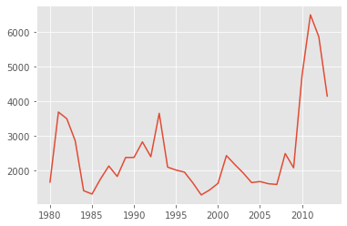

```python
haiti.plot()
```

#### Let's change the index values of Haiti to type integer for plotting, and label the x and y axes

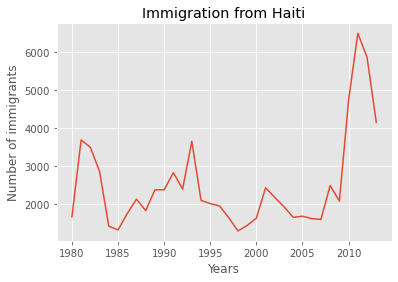

```python
haiti.index = haiti.index.map(int) # let's change the index values of Haiti to type integer for plotting
haiti.plot(kind='line')

plt.title('Immigration from Haiti')
plt.ylabel('Number of immigrants')
plt.xlabel('Years')

plt.show() # need this line to show the updates made to the figure
```

#### Let's annotate this spike in the plot "year 2010" (it was due to an earthquake in Haiti)

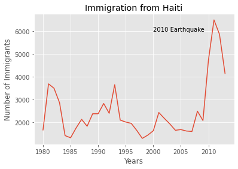

```python
haiti.plot(kind='line')

plt.title('Immigration from Haiti')
plt.ylabel('Number of Immigrants')
plt.xlabel('Years')

# annotate the 2010 Earthquake.
# syntax: plt.text(x, y, label)
plt.text(2000, 6000, '2010 Earthquake')

plt.show()
```

### Let's compare the number of immigrants from India and China from 1980 to 2013:

```python
df_CI = df_can.loc[['India', 'China'], years]
df_CI
```

| Country | 1980 | 1981 | 1982 | 1983 | 1984 | 1985 | 1986 | 1987 | 1988 | 1989 | ... | 2004 | 2005 | 2006 | 2007 | 2008 | 2009 | 2010 | 2011 | 2012 | 2013 |
| --- | --- | --- | --- | --- | --- | --- | --- | --- | --- | --- | --- | --- | --- | --- | --- | --- | --- | --- | --- | --- | --- |
| India | 8880.0 | 8670.0 | 8147.0 | 7338.0 | 5704.0 | 4211.0 | 7150.0 | 10189.0 | 11522.0 | 10343.0 | ... | 28235.0 | 36210.0 | 33848.0 | 28742.0 | 28261.0 | 29456.0 | 34235.0 | 27509.0 | 30933.0 | 33087.0 |
| China | 5123.0 | 6682.0 | 3308.0 | 1863.0 | 1527.0 | 1816.0 | 1960.0 | 2643.0 | 2758.0 | 4323.0 | ... | 36619.0 | 42584.0 | 33518.0 | 27642.0 | 30037.0 | 29622.0 | 30391.0 | 28502.0 | 33024.0 | 34129.0 |

2 rows × 34 columns

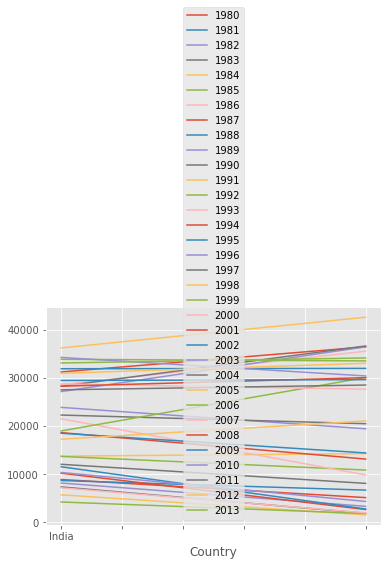

```python
# plotting a graph
df_CI.plot(kind='line')
```

#### Not working, we need to transpose the x and y axis:

```python
df_CI = df_CI.transpose()
df_CI.head()
```

| Country | India | China |
| --- | --- | --- |
| 1980 | 8880.0 | 5123.0 |
| 1981 | 8670.0 | 6682.0 |
| 1982 | 8147.0 | 3308.0 |
| 1983 | 7338.0 | 1863.0 |
| 1984 | 5704.0 | 1527.0 |

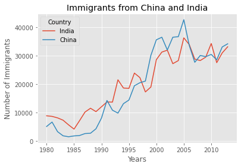

```python
# Now, let's try again
df_CI.index = df_CI.index.map(int) # let's change the index values of df_CI to type integer for plotting
df_CI.plot(kind='line')

plt.title('Immigrants from China and India')
plt.ylabel('Number of Immigrants')
plt.xlabel('Years')

plt.show()
```

```python
inplace = True # paramemter saves the changes to the original df_can dataframe

df_can.sort_values(by='Total', ascending=False, axis=0, inplace=True)

# get the top 5 entries
df_top5 = df_can.head(5)

# transpose the dataframe
df_top5 = df_top5[years].transpose()

print(df_top5)
```

[output not shown]

#### 2. Plot the dataframe. To make the plot more readeable, we will change the size using the `figsize` parameter.

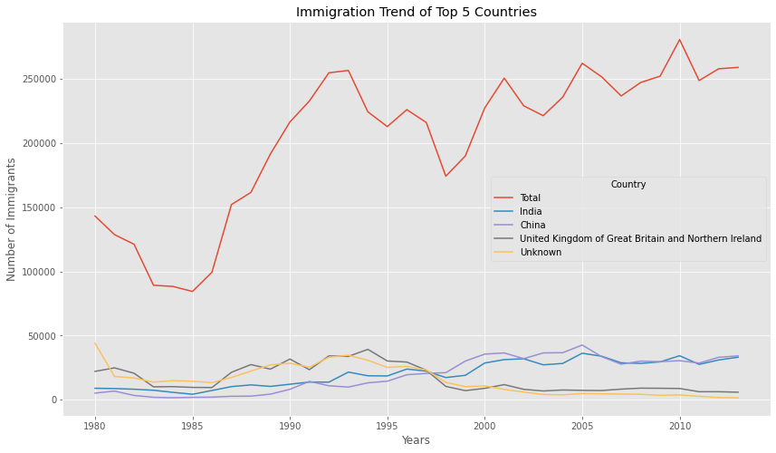

```python
df_top5.index = df_top5.index.map(int) # let's change the index values of df_top5 to type integer for plotting
df_top5.plot(kind='line', figsize=(14, 8)) # pass a tuple (x, y) size

plt.title('Immigration Trend of Top 5 Countries')
plt.ylabel('Number of Immigrants')
plt.xlabel('Years')

plt.show()
```